# 95-868 Mini-Project

Matthew Herpich (mherpich)

## Introduction

### Overview

The purpose of this assignment was to explore the R data set `nlschools` (in the `MASS` library). This dataset contains records for 2287 students in the Netherlands and has the following dimensions:

- `lang`: their test score on a language exam
- `IQ`: their verbal IQ
- `class`: the ID number for their classroom
- `GS`: the number of students in each class
- `SES`: the socio-economic status of their family
- `COMB`: was the student in a multi-grade class? (0=no, 1=yes)

In particular, this assignment focused on three main questions regarding the dataset:

1. Are there discrepancies in `IQ` or `SES` in the different classes, or when grouping by multi-grade vs non-multi-grade classes?
2. When did students perform better or worse on the language exam? Describe which variables had the most important effects.
3. Do you think there are interactions in the effects of the variables on the language exam score? Speculate as to the cause of any such effects that you think should be included.

### Initial Data Exploration

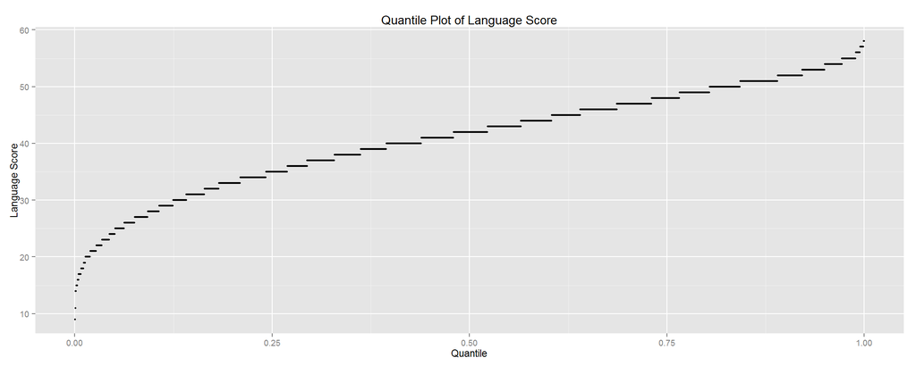

When viewed on a QQ plot against a normal distribution, the language scores seem to fit the normal assumption for low and mid-range scores; however, the distribution appears to deviate from the normal assumption at the higher end, likely due to the fact the test had a capped maximum score.

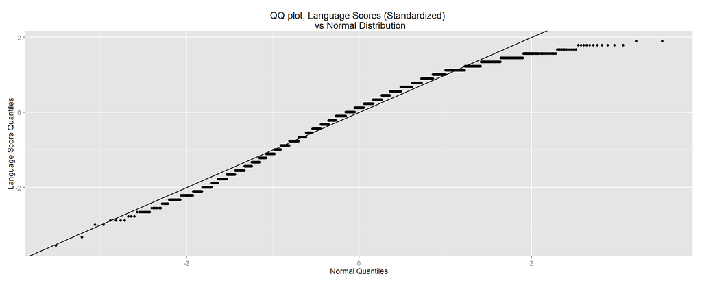

Two important predictor variables which will be used in this analysis are `IQ`, the students’ verbal IQ score, and `SES`, a measure of the students’ socioeconomic conditions (higher score = more affluent). As shown by the QQ plots below, the verbal IQ score seems to behave well against a normal distribution; however, the SES measure has a different, more nuanced behavior. Given these scores also seem capped at the low and high ends, a distribution QQ plot does not behave as we would expect at the tails. In the middle range, however, it does appear the distribution of SES scores most closely resembles a log-normal distribution, which is intuitive given the distribution of wealth in many countries is highly skewed.

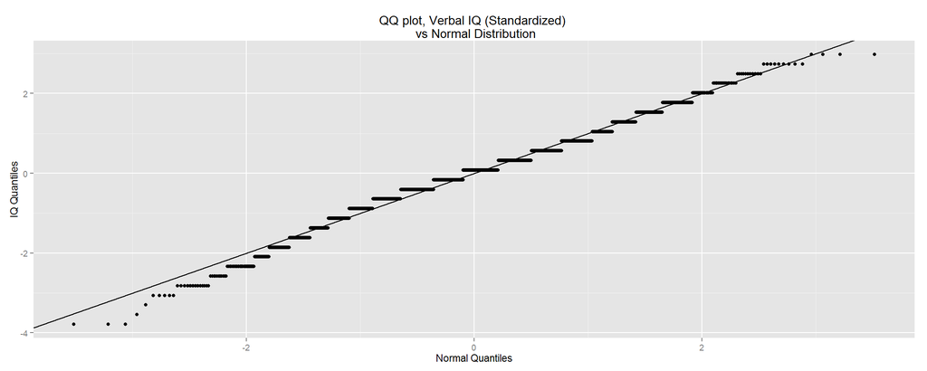

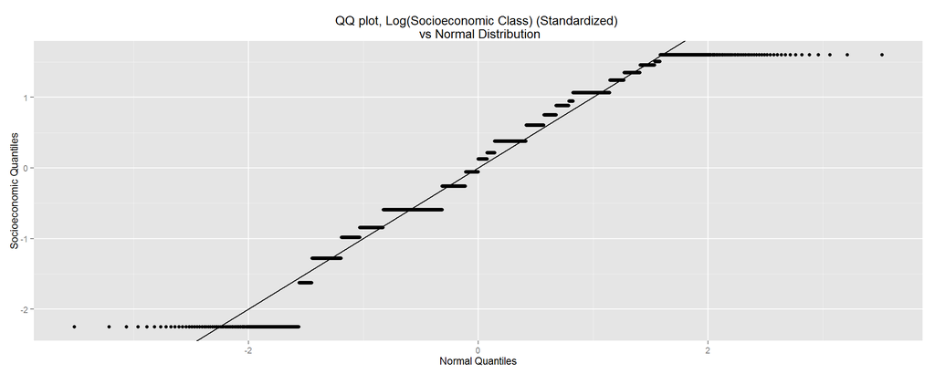

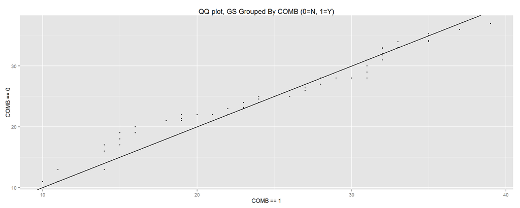

## Analysis

### Part 1: Distribution of IQ and SES Among Classes

The first part of the assignment explores the relationship of `IQ` and `SES` among the 133 different classes in the dataset. To check to see if the classes have a relatively consistent distribution of `IQ` and `SES`, I first ranked all of the 133 classes by their average `IQ` and `SES` scores. I then took 8 subsets of the 133 classes, with the first subset representing the 17 classes with the highest averages, the second subset representing the 17 classes with the second highest averages, and so forth. Finally, I created quantile plots for each class subset against the pooled quantile plot for all of the classes.

As evidenced by the faceted charts below, the distribution of both `IQ` and `SES` is not uniform across the classes; in fact, there is a relatively wide disparity between the classes with the highest `IQ`/`SES` scores and the classes with the lowest `IQ`/`SES` scores. Also, it seems the disparity among classes is more pronounced in the distribution of `SES` scores versus `IQ` scores, a result which makes sense given the distribution of such scores appears log-normal for much of its range.

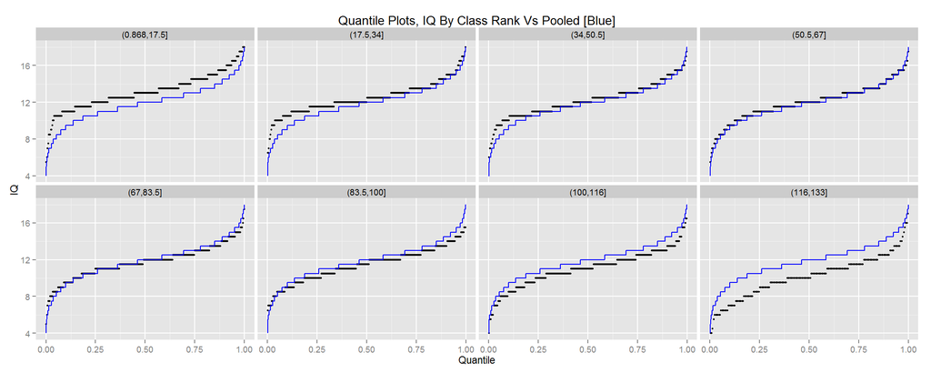

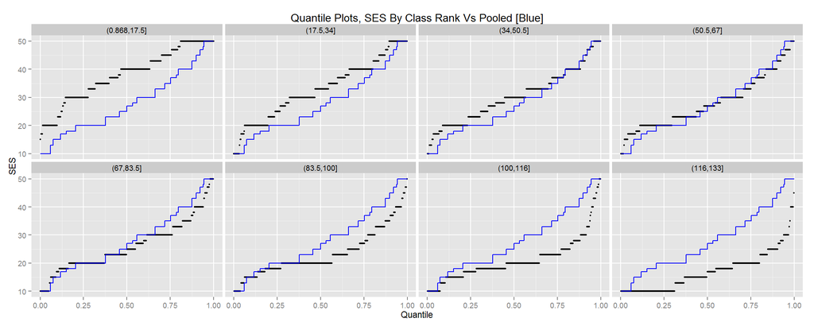

Still of interest with respect to the distribution of `IQ` and `SES` scores among classes is whether or not there is a pronounced difference among multi-grade classes (`COMB` = 1) or single-grade classes (`COMB` = 0). To answer this question, I created quantile-quantile plots for the subsets of `COMB` = 1 or `COMB` = 0 for both `IQ` and `SES` scores and plotted these subsets against the y = x reference line. If all the points lie along the y = x reference line, the distribution among the subsets is consistent. However, as evidenced for both `IQ` and `SES`, the points in the QQ plot lie primarily above the y = x reference line, implying that the `IQ` and `SES` scores for the single-grade classes was uniformly better across all quantiles. This effect is not very pronounced, as the points do not lie a far distance from the reference line, but it does appear to be present in the data.

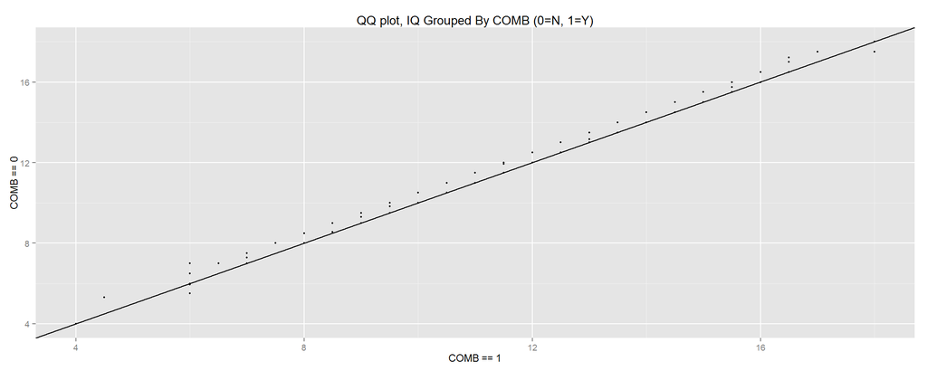

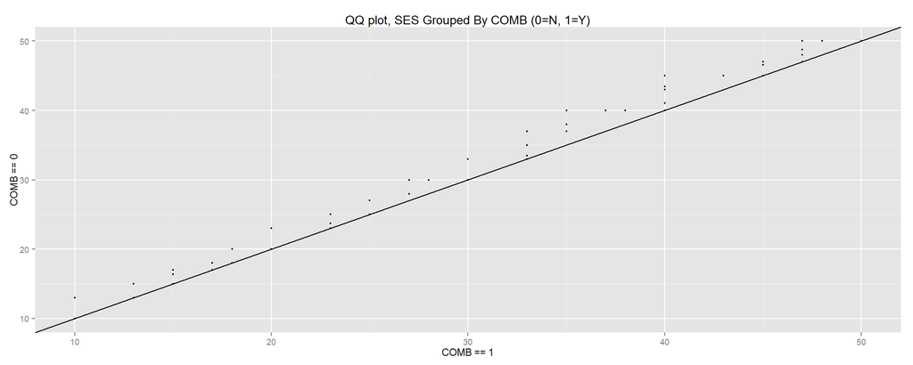

As an addendum, one other interesting relationship to explore is the correlation between the rank of the class for verbal `IQ` versus the rank of the class for `SES` score. A highly correlated rank-rank plot would imply that classes with higher average `IQ` also tended to be wealthier and vice versa. As evidenced by the data, there is a noticeable positive linear trend between the predictor variables; however, the rank-rank correlation coefficient of 0.42 implies a modest trend at best. Thus, it is not apparent that a particular class’ ranked average `IQ` is a strong predictor of its ranked average `SES`.

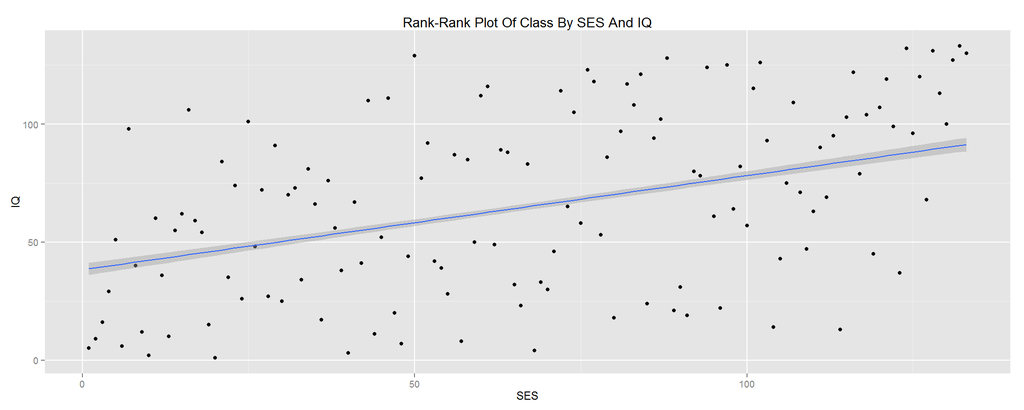

Correlation Coefficient (rank `SES` vs rank `IQ`): 0.4175502

### Part 2: Impact of Predictor Variables on Language Exam Score

#### Linear Model

To explore the impact of predictor variables on language exam score, I first started with the assumption of a multivariate linear model. For purposes of this analysis, I removed the class variable, as a linear relationship between the language exam score and class does not make sense for this type of analysis (i.e., the score of the language exam depended on the students in the class and not the actual class number). As shown below, I first defined the full model to include all of the potential predictive variables and subsequently used backward stepwise regression to remove variables which did not materially improve the model’s overall AIC score.

```
## Start:  AIC=8860.79
## lang ~ IQ + GS + SES + COMB
##
##        Df Sum of Sq    RSS    AIC
## - GS    1        50 109699 8859.8
## <none>              109649 8860.8
## - COMB  1      1289 110938 8885.5
## - SES   1      5291 114940 8966.6
## - IQ    1     50231 159880 9721.3
##
## Step:  AIC=8859.83
## lang ~ IQ + SES + COMB
##
##        Df Sum of Sq    RSS    AIC
## <none>              109699 8859.8
## - COMB  1      1287 110986 8884.5
## - SES   1      5241 114940 8964.6
## - IQ    1     50231 159930 9720.0
```

```
## (Intercept)          IQ         SES       COMB1
##   9.0351894   2.3905743   0.1464239  -1.6830126
```

The result of the linear model indicated the significant predictor variables of the students’ language exam scores included their verbal `IQ`, `SES` score, and whether or not the class was single-grade or multi-grade (`COMB` factor variable). Based on this analysis, both `IQ` and `SES` seemed to have positive linear effects on the language exam score, while the `COMB` factor variable had a negative adjustment of -1.68 to the language score for multi-grade classes versus single-grade classes.

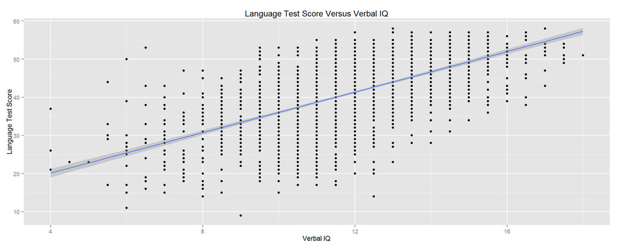

Correlation Coefficient (`IQ` vs `lang`): 0.6098195

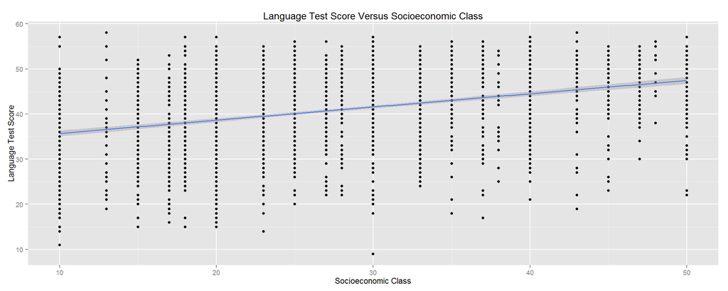

Correlation Coefficient (`SES` vs `lang`): 0.3553277

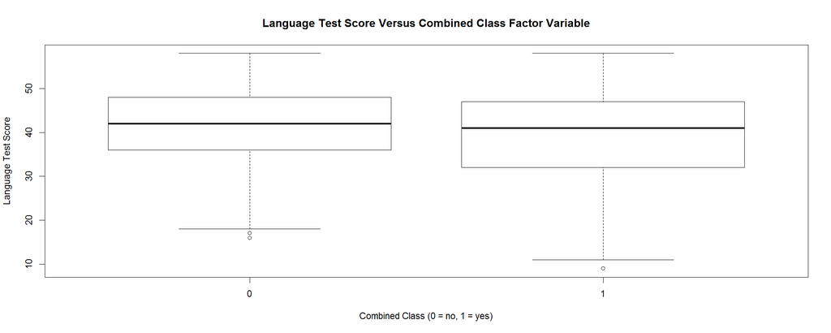

With respect to `GS`, a simple scatterplot versus language test score does not seem to reveal any statistically significant predictive relationship, a result which seems to substantiate removing it from the linear model.

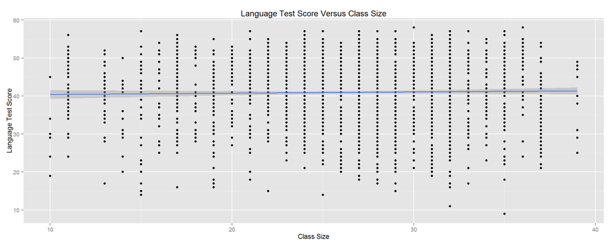

The linear models were informative in that they helped remove the `GS` variable (number of students in each class) from the list of significant predictors of language score and helped to illustrate the overall positive or negative trend for each potential predictor against the language score.

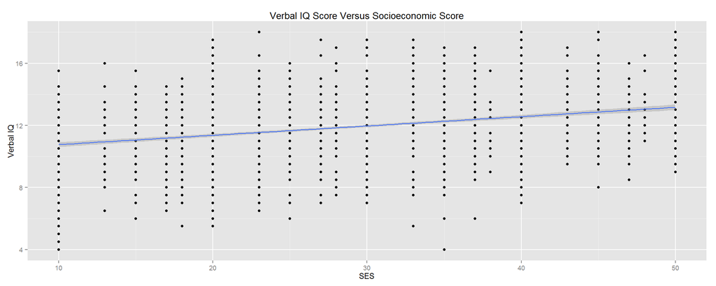

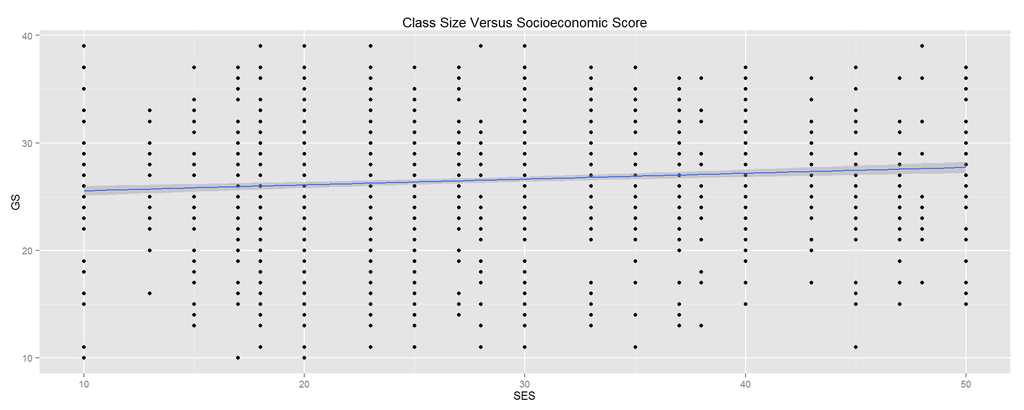

#### Non-Linear Models

Of the predictor variables generated from the linear model, only `IQ` and `SES` can be fit utilizing a spline model (`COMB` is not a continuous predictor, rather a factor variable). Thus, I first pieced apart the predictors and generated lists of potential linear and nonlinear terms which would be used in the nonlinear predictor model of language score. I then utilized the generalized additive model (“GAM”) package in R to test the terms’ AIC to determine if nonlinear terms should be included in the final model.

For `IQ`, the GAM produced a linear term as the final output, thereby validating the linear assumption generated in the first part of this exercise.

```
## Start:  lang ~ 1; AIC= 16545.2
## Step:1 lang ~ IQ ; AIC= 15483.69
```

For `SES`, the GAM produced a spline with 3 degrees of freedom, emphasizing the nonlinearity of the relationship between language score and `SES` score. I then plotted a spline model relative to the underlying data to check if the model does in fact follow the distribution. As evidenced by the plot below, a spline model with 3 degrees of freedom does seem to fit the `SES` data trend well.

```
## Start:  lang ~ 1; AIC= 16545.2
## Step:1 lang ~ SES ; AIC= 16238.52
## Step:2 lang ~ ns(SES, df = 2) ; AIC= 16218.87
## Step:3 lang ~ ns(SES, df = 3) ; AIC= 16211.03
```

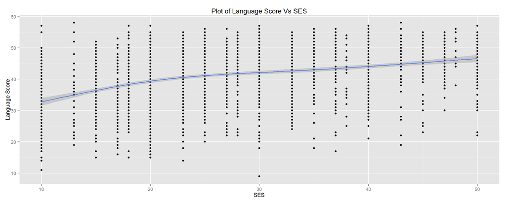

### Part 3: Interactions of Predictor Variables

#### Tracking Interactions Using Coplots

The final part of the exercise involved tracking the potential interactions between predictor variables and whether or not such interactions should be considered when modeling language exam scores. For purposes of this project, I focused on interactions among the three predictor variables outlined in Part 2: `IQ`, `SES`, and `COMB`. For each of the predictor variables, I created coplots against the language score faceted by one of the other predictor variables (e.g., `SES` versus `lang` for each subset of `IQ`). The results of this analysis yielded some interesting behaviors. Based on the coplots, it seems that the impact of `SES` on language scores diminished as `IQ` increased, while the impact of `IQ` on language scores seemed to remain about the same across all `SES` scores. Additionally, being in a multi-grade class seemed to create less of a disparity to being in a single-grade class for higher `IQ` and `SES` scores.

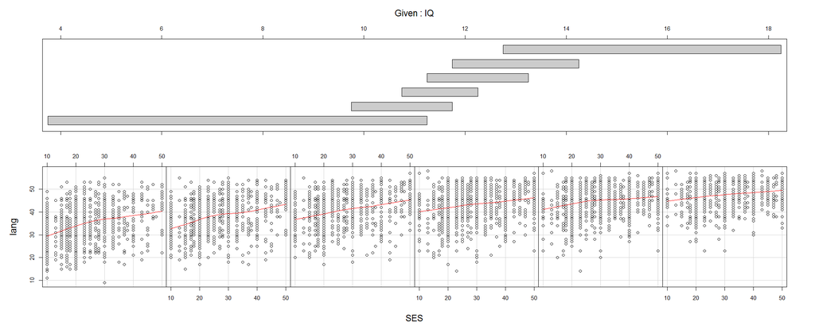

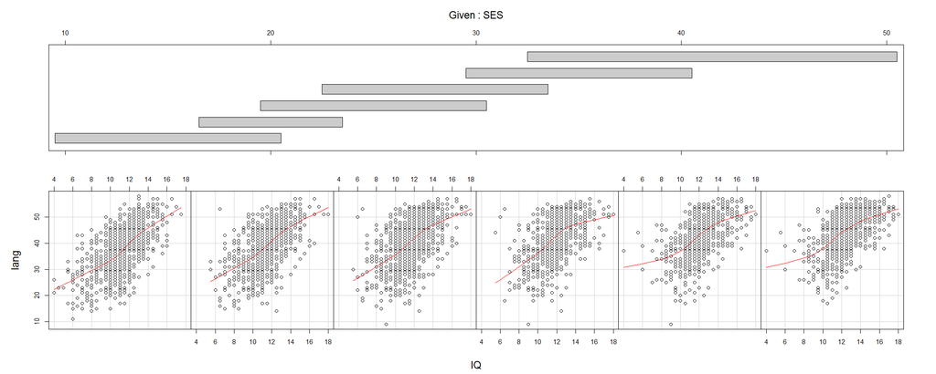

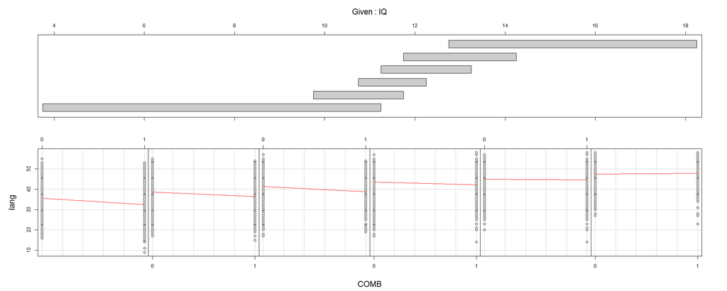

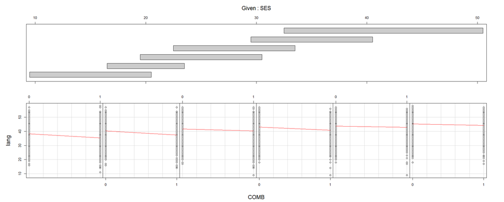

#### Adding Interaction Terms To Model

The final part of the project was to utilize the non-linear GAM model derived previously and incorporate potential interaction terms among the predictor variables to create a “finalized” GAM. To accomplish this task, I utilized the step() function to create a GAM utilizing a forward stepwise regression model beginning with the non-linear model and subsequently incorporating significant interaction terms between the predictors. As shown below, the step() function determined that the model should be enhanced with the interaction between `IQ` and `COMB`. This interaction makes sense given the coplot results - at higher `IQ`, the disparity between language score for single-grade and multi-grade classes seems to lessen.

```
## Start:  AIC=8855.32
## lang ~ IQ + COMB + ns(SES, df = 3)
##
##           Df Sum of Sq    RSS    AIC
## + IQ:COMB  1    708.20 108583 8842.5
## <none>                 109292 8855.3
## + GS       1     48.96 109243 8856.3
##
## Step:  AIC=8842.46
## lang ~ IQ + COMB + ns(SES, df = 3) + IQ:COMB
##
##        Df Sum of Sq    RSS    AIC
## <none>              108583 8842.5
## + GS    1    67.554 108516 8843.0
```

```
## lang ~ IQ + COMB + ns(SES, df = 3) + IQ:COMB
```

Incorporating the non-linear component with respect to the `SES` predictor helped eliminate interaction terms which would ordinarily have been incorporated utilizing a backward stepwise multivariate regression model. Also, interestingly, when the model is allowed to include interaction terms among all predictors, `GS` becomes a significant predictor of language score.

```
##  (Intercept)           IQ           GS          SES        COMB1
##   7.00930100   2.71317416  -0.06741970   0.37166874 -11.11733859
##       IQ:SES     IQ:COMB1     GS:COMB1
##  -0.01862168   0.57304540   0.10321079
```

## Conclusion

In conclusion, based on the approaches described above, I was able to parse the nlschools data available via the R `MASS` library to find interesting relationships among various attributes related to school children in the Netherlands. In particular, I was able to determine that average verbal IQ and socioeconomic data among classes is skewed and that multi-grade classes tended to have uniformly lower verbal IQ and socioeconomic scores versus single-grade classes. With respect to predicting the children’s performance on a language test, the most significant predictors of score included `IQ`, which had a positive linear effect, `SES`, which had a positive non-linear effect, and `COMB`, which in a best-fit model should also be viewed in the context of `IQ` (at higher `IQ`, the disparity between `COMB`=0 and `COMB`=1 tended to diminish).